# Richer and Poorer

Dmitry Shkolnik

September 13, 2017

## Getting Census Data

We retrieve Census data using the **cancensus** R library. This library provides an interface to Statistics Canada Census data for 2016, 2011, and 2006.

```r
library(cancensus)

# Get dataset codes for different census products
list_census_datasets()
```

```
## Querying CensusMapper API for available datasets...
```

```
## # A tibble: 3 x 2
##   dataset                description
## *   <chr>                      <chr>
## 1    CA06         2006 Canada Census
## 2    CA11 2011 Canada Census and NHS
## 3    CA16         2016 Canada Census
```

Select all current Canadian census metropolitan agglomerations. We can use a built-in function for searching and selecting Canadian census regions. We want to filter to select only CMA level geography for this analysis.

```r
cma <- list_census_regions("CA16") %>%
  filter(level=='CMA')
cma
```

```
## # A tibble: 49 x 5
##    region                             name level     pop municipal_status
##     <chr>                            <chr> <chr>   <int>            <chr>
##  1  35535                          Toronto   CMA 5928040                B
##  2  24462                         Montréal   CMA 4098927                B
##  3  59933                        Vancouver   CMA 2463431                B
##  4  48825                          Calgary   CMA 1392609                B
##  5    505                Ottawa - Gatineau   CMA 1323783                B
##  6  48835                         Edmonton   CMA 1321426                B
##  7  24421                           Québec   CMA  800296                B
##  8  46602                         Winnipeg   CMA  778489                B
##  9  35537                         Hamilton   CMA  747545                B
## 10  35541 Kitchener - Cambridge - Waterloo   CMA  523894                B
## # ... with 39 more rows
```

Another auxiliary function `as_census_region_list` takes a subset of regions and stores as a region_list object for easy use in subsequent queries.

```r
cma_list <- cma %>% as_census_region_list
cma_list
```

```
## $CMA
##  [1] "35535" "24462" "59933" "48825" "505"   "48835" "24421" "46602"
##  [9] "35537" "35541" "35555" "35539" "12205" "35532" "59935" "35559"
## [17] "47725" "47705" "24433" "10001" "35568" "59915" "59932" "35580"
## [25] "35521" "24408" "24442" "35550" "13305" "35543" "13310" "35529"
## [33] "35595" "48810" "59938" "59925" "35522" "13320" "59930" "48830"
## [41] "35562" "24447" "59970" "24450" "35590" "48805" "48860" "35575"
## [49] "48850"
```

Raw census data has thousands of variables across deeply nested parent/child hierarchies. In this case, we are solely interested in full-time, full-year (FTFY) median incomes. We can search for strings in variable labels and descriptions to find the codes for the variable we need using `search_census_vectors(“text”,“dataset”).

```r
vectors11 <- search_census_vectors("income","CA11")
```

[output not shown]

```r
vectors11
```

```
## # A tibble: 137 x 7
##          vector   type
##           <chr> <fctr>
##  1 v_CA11N_2277  Total
##  2 v_CA11N_2278  Total
##  3 v_CA11N_2279  Total
##  4 v_CA11N_2280  Total
##  5 v_CA11N_2283  Total
##  6 v_CA11N_2290  Total
##  7 v_CA11N_2293  Total
##  8 v_CA11N_2294   Male
##  9 v_CA11N_2295 Female
## 10 v_CA11N_2296  Total
## # ... with 127 more rows, and 5 more variables: label <chr>, units <fctr>,
## #   parent_vector <chr>, aggregation <chr>, description <chr>
```

We’re interested in median total income for individuals so the variable we want to extract here is `v_CA11N_2341`.

We run the search twice, once for the 2011 dataset and once for the 2016 dataset as they may have different variable coding and structure.

```r
vectors16 <- search_census_vectors("income","CA16")
```

[output not shown]

```r
vectors16
```

```
## # A tibble: 122 x 7
##         vector   type
##          <chr> <fctr>
##  1 v_CA16_2201  Total
##  2 v_CA16_2202   Male
##  3 v_CA16_2203 Female
##  4 v_CA16_2204  Total
##  5 v_CA16_2205   Male
##  6 v_CA16_2206 Female
##  7 v_CA16_2207  Total
##  8 v_CA16_2208   Male
##  9 v_CA16_2209 Female
## 10 v_CA16_2210  Total
## # ... with 112 more rows, and 5 more variables: label <chr>, units <fctr>,
## #   parent_vector <chr>, aggregation <chr>, description <chr>
```

The variable we want for the 2016 data is `v_CA16_2207`.

## Changes in Income, 2011-2016

Once we have identified the right variables, getting the data is very straightforward.

```r
inc11 <- get_census(dataset = "CA11", regions = cma_list, vectors = "v_CA11N_2341",level = "CMA", geo_format = NA, labels = "short")
head(inc11)
```

```
## # A tibble: 6 x 9
##   GeoUID   Type   `Region Name` `Area (sq km)` Population Dwellings
##    <chr> <fctr>          <fctr>          <dbl>      <dbl>     <dbl>
## 1  10001    CMA  St. John's (B)       850.3769     196966     84542
## 2  12205    CMA     Halifax (B)      5963.0360     390328    177295
## 3  13305    CMA     Moncton (B)      2471.0914     138644     62403
## 4  13310    CMA  Saint John (B)      3645.0410     127761     56775
## 5  13320    CMA Fredericton (K)      4966.1479      94268     41581
## 6  24408    CMA    Saguenay (B)      2876.8337     157790     73766
## # ... with 3 more variables: Households <dbl>, `NHS Non Return
## #   Rate` <dbl>, v_CA11N_2341 <dbl>
```

```r
inc16 <- get_census(dataset = "CA16", regions = cma_list, vectors = "v_CA16_2207",level = "CMA", geo_format = NA, labels = "short")
head(inc16)
```

```
## # A tibble: 6 x 8
##   GeoUID   Type   `Region Name` `Area (sq km)` Population Dwellings
##    <chr> <fctr>          <fctr>          <dbl>      <dbl>     <dbl>
## 1  10001    CMA  St. John's (B)       850.4604     205955     92353
## 2  12205    CMA     Halifax (B)      5963.1371     403390    187478
## 3  13305    CMA     Moncton (B)      2625.1211     144810     66699
## 4  13310    CMA  Saint John (B)      3793.4216     126202     58398
## 5  13320    CMA Fredericton (K)      5881.7274     101760     46459
## 6  24408    CMA    Saguenay (B)      3078.7992     160980     77968
## # ... with 2 more variables: Households <dbl>, v_CA16_2207 <dbl>
```

```r
cpi2010 <- 116.3
cpi2015 <- 126.9
cpi_adj <- cpi2015/cpi2010
inc11 <- inc11 %>% mutate(median_income_adj = v_CA11N_2341 * cpi_adj)
```

Combining the two datasets we can start making comparisons across Census periods. In addition, we want to clean up the CMA variable text to keep just the name, remove the two new CMAs that are not possible to make a comparison for (Grande Prairie and Wood Buffalo), and generate a trend (positive or negative) that reflects whether incomes, adjusted for inflation, have increased or decreased in that CMA.

```r
inc <- inc11 %>%
  inner_join(inc16, by = "GeoUID", suffix = c("2011","2016")) %>%
  select(GeoUID, CMA = `Region Name2011`, inc2011 = v_CA11N_2341,inc2011_adj = median_income_adj, inc2016 = v_CA16_2207) %>%
  filter(!is.na(inc2011)) %>%
  mutate(CMA = as.factor(gsub(" \\(.\\)","", CMA)))

inc$trend <- ifelse(inc$inc2016 >= inc$inc2011_adj, "Positive","Negative")
```

It can be difficult to visually comunicate changes in variables when you have this many factors. As we’re interested primarily two things: the difference between Census period and the relative income between CMAs, an effective visualization would prioritize information space for those two properties. Barbell plots do just this, and are easy to generate using the `ggplot2` and an additional CRAN package called `ggalt` which provides additional geoms like barbells - [among several others](https://cran.r-project.org/web/packages/ggalt/vignettes/ggalt_examples.html).

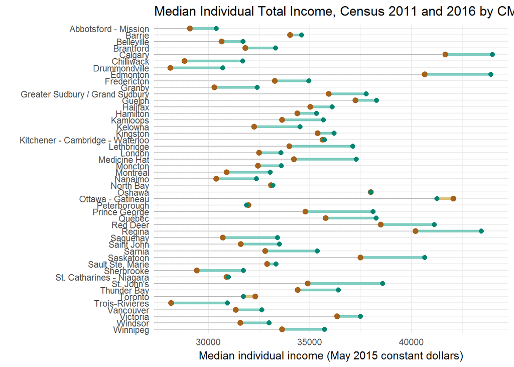

```r
# install.packages("ggalt")
library(ggplot2)
library(ggalt)
ggplot(inc, aes(y = CMA, x= inc2011_adj, xend = inc2016)) +
  geom_dumbbell(size = 1.25, color = "#80cdc1",
                colour_x = "#a6611a", colour_xend = "#018571",
                size_x = 2.25, size_xend = 2,
                dot_guide = TRUE, dot_guide_size = 0.10,
                show.legend = TRUE) +
  geom_dumbbell(data = inc[inc$trend == "Negative",], aes(y = CMA, x= inc2011_adj, xend = inc2016),
                size = 1.25, color = "#dfc27d",
                colour_x = "#a6611a", colour_xend = "#018571",
                size_x = 2.25, size_xend = 2,
                dot_guide = TRUE, dot_guide_size = 0.10,
                show.legend = TRUE) +
  scale_y_discrete(name="", limits = rev(levels(inc$CMA))) +
  scale_x_continuous("Median individual income (May 2015 constant dollars)") +
  labs(title = "Median Individual Total Income, Census 2011 and 2016 by CMA") +
  theme_minimal()
```

We see that incomes have in just about every Canadian CMA by varying amounts. There are notable exceptions, however, in Toronto and Ottawa - Gatineau, which saw declines between the two Census periods.

## About cancensus

This analysis uses the **cancensus** R package developed by [Jens von Bergmann](https://github.com/mountainMath), [Aaron Jacobs](https://github.com/atheriel), and [myself](https://github.com/dshkol) to access Canadian Census data. We hope to have **cancensus** available via CRAN in the near future, but in the meantime you can install it directly off of Github. Additional information about how to get an API key, as well as other examples and demos are on the **cancensus** [Github page](https://github.com/mountainMath/cancensus).

```r
devtools::install_github("mountainmath/cancensus")
options(cancensus.api_key = "your_api_key")
```